# Table of Contents

```python
import os
import pickle

import pandas as pd
from matplotlib import pyplot as plt
import seaborn as sns
import numpy as np
import scipy.stats as st

sns.set()

## A small hack to make sure we are in the correct folder
cwd = os.getcwd()
folder_name = os.path.basename(cwd)
if folder_name != 'uas-package':
    os.chdir('../')

from simuas.Util import Package

%matplotlib inline
```

## Load Data

Here we will load our saved data from the simulation. This is a list (array) where every element contains data about one replication. Each replication contains the following:

1. Time series of number of charging stations used.
2. Time series of number of packages waiting for a UAS (queue length).
3. Time series for the number of batteries available in the 'battery bank' resource.
4. Time series for the number of UAS fully available in the 'UAS bank' resource.
5. A list of all pacakges delivered. Each pacakge holds detailed information such as - time to wait for a UAS, flight time, total deliver time, etc.
6. An error list. Each element contains an error record (low battery, uas collison)

```python
raw_data = pickle.load( open( "./data/repl_results_dual.p", "rb" ) )
```

```python
def plot_historgram(raw_data, i, pc=0):
    """This function plots historgrams for one replication (indexed by i)
    """
    data = raw_data[i][pc]
    package_df = pd.DataFrame(data['packages'], columns=Package._fields).dropna()

    fig, ax = plt.subplots(1, 4, figsize=(16,4))
    subplots = [('uas_queue', 'Package Queue (# Waiting for UAS)'),('battery_bank', 'Number of Available Batteries'),
     ('charging_stations', 'In Use Battery Charging Stations') ]

    sns.distplot(package_df['uas_wait'], kde=False, ax=ax[0])
    ax[0].set_title('Package Wait Time (for UAS)')
    ax[0].set_ylabel('# of Pacakges')
    ax[0].set_xlabel('Minutes')

    for i, (key, title) in enumerate(subplots):
        bb = data[key]['item_time_dict']
        sns.distplot(list(bb.keys()), bins=25, ax=ax[i+1], kde=False, hist_kws={'weights': list(bb.values())})
        ax[i+1].set_title(title)
        ax[i+1].set_ylabel('Minutes')

    fig.subplots_adjust(wspace=.25)

def plot_time_series(raw_data, i=1):
    data
```

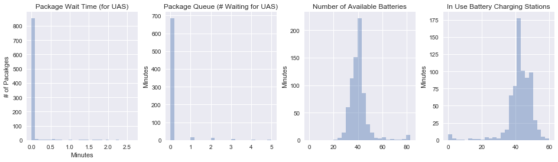

```python
plot_historgram(raw_data, 0) # plot some data for FIRST replication
```

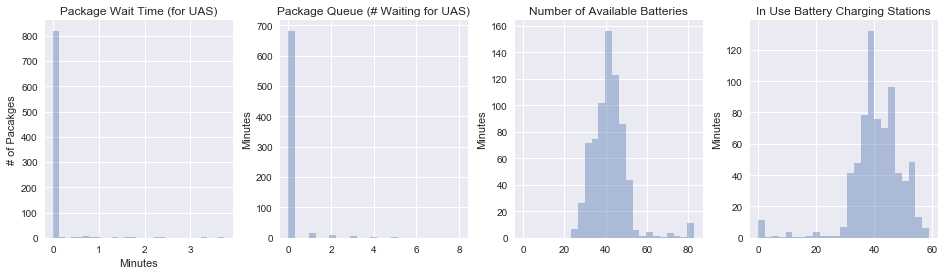

```python
plot_historgram(raw_data, 1) # plot some data for SECOND replication
```

## Dataframe

The following function will turn our raw data into dataframes, really nice tabular data structures which make it easy to visualize.

```python
def repl_df_items(raw_data, field, columns, num_repl=2):
    num_pc = len(raw_data[0])
    df = pd.DataFrame()
#     df = pd.DataFrame(raw_data[0][0][field], columns=columns).dropna()
#     df['replication'] = 0
#     df['package_center'] = 0
    for j in range(num_repl):
        for pc in range(num_pc):
            repl= raw_data[j][pc]
            df_new = pd.DataFrame(repl[field], columns=columns).dropna()
            df_new['replication'] = j
            df_new['package_center'] = pc
            df = df.append(df_new)
    df['dummy'] = 0
    return df

def make_df_ts(repl, repl_num, field):
    """
    Makes a new data frame for a replication. Records the package center it came from as well
    """
    num_pc = len(repl) # number of pacakge centers
    # repl[package center][field of interest][time or value]
    df = pd.DataFrame()
    for pc in range(num_pc):
        df_new = pd.DataFrame({
                'time': repl[pc][field]['cumulative_time_rec'],
                'item': repl[pc][field]['cumulative_item_rec'],
                })
        df_new = df_new.drop_duplicates(subset='time')
        df_new['replication'] = repl_num + 1
        df_new['pacakge_center'] = pc + 1
        df = df.append(df_new)
    return df

def make_df_ts_field(raw_data, field, num_repl=2):
#     repl = raw_data[0][0][field]
#     df = make_df_ts(repl, 0)
    df = pd.DataFrame()
    # Loop through replications
    for j in range(0, num_repl):
        repl = raw_data[j] # get replication data set
        # create a new data frame that for this replication for all pacakge centers
        df_new = make_df_ts(repl, j, field)
        df = df.append(df_new)
    df['field'] = field
    return df

def repl_df_ts(raw_data, fields=['charging_stations', 'uas_queue', 'battery_bank', 'uas_bank'], num=2):
    list_df = [make_df_ts_field(raw_data, field_name, num)  for field_name in fields]
    df = pd.concat(list_df)
    return df
```

```python
package_ts_df = repl_df_items(raw_data, 'packages', Package._fields, 5)
# package_ts_df
# sns.tsplot(time="count", value="uas_wait", unit='dummy',condition="replication", data=package_ts_df)
```

[output not shown]

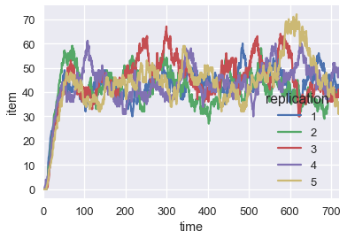

```python
ts_df = repl_df_ts(raw_data, num=5)

field_df = ts_df[ts_df['field'] == 'charging_stations']
sns.tsplot(time="time", value="item", unit='field',condition="replication", data=field_df)
```

## Battery Charge Times

The following code generates graphs for the number of charging stations and batteries bank level throughout simulation time. We also use ordered statistics to create a bound on what we believe will be the minimum number of batteries and charging stations required so that UAS always have charged batteries.

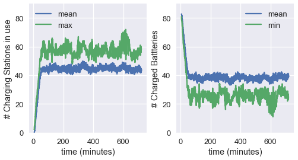

```python
sns.set_context("talk")
def plot_time_series(df, ax, do_max=True):
    maxormin = 'max' if do_max else 'min'
    rolling_avg_mean = df['item'].rolling(window=50).mean()
    if do_max:
        rolling_avg_maxormin = df['item'].rolling(window=50).max()
    else:
        rolling_avg_maxormin = df['item'].rolling(window=50).min()
    rolling_avg_mean.plot(ax=ax)
    rolling_avg_maxormin.plot(ax=ax)
    ax.legend(["mean", maxormin]);
    ax.set_ylim(0,90)
    ax.set(xlabel='time (minutes)')

def plot_charging(raw_data, num=5):
    ts_df = repl_df_ts(raw_data, num=num)
    fig, (ax1,ax2) = plt.subplots(1, 2, figsize=(8,4))
    fig.subplots_adjust(wspace=0.25)
    # ts_df = ts_df.reset_index(drop=True)
    charging_df = ts_df[ts_df['field'] == 'charging_stations'][['time', 'item', 'replication']].set_index('time').sort_index()
    battery_df = ts_df[ts_df['field'] == 'battery_bank'][['time', 'item', 'replication']].set_index('time').sort_index()
#     battery_df['item'] = 100 - battery_df['item']
    plot_time_series(charging_df, ax1)
    plot_time_series(battery_df, ax2, do_max=False)
    ax1.set(ylabel='# Charging Stations in use')
    ax2.set(ylabel='# Charged Battteries')
    fig.savefig('imgs/charging_stations_and_battery.png', bbox_inches='tight')

    return charging_df, battery_df, ts_df

charging_df, battery_df, ts_df = plot_charging(raw_data, num=30)
```

```python
mean_charging = charging_df.loc[charging_df.index > 60].mean()
max_charging = charging_df.loc[charging_df.index > 60].max()

mean_battery = battery_df.loc[battery_df.index > 60].mean()
max_battery = battery_df.loc[battery_df.index > 60].min()

# print(mean_charging.iloc[0])
print('Charging Stations - Mean: {:.2f}; Max: {:.2f}'.format(mean_charging.iloc[0], max_charging.iloc[0]))
print('Battery Bank - Mean: {:.2f}; Max: {:.2f}'.format(mean_battery.iloc[0], max_battery.iloc[0]))
charging_quantile_max = charging_df.groupby(['replication']).max().quantile(q=.95)
battery_quantile_min = battery_df.groupby(['replication']).min().quantile(q=.05)
print('95 Percent Sure Chargin Stations Required - {:.2f}'.format(charging_quantile_max.iloc[0]))
print('95 Percent Sure Battery Required - {:.2f}'.format(100 - battery_quantile_min.iloc[0]))
```

```
Charging Stations - Mean: 44.78; Max: 72.00
Battery Bank - Mean: 38.23; Max: 11.00
95 Percent Sure Chargin Stations Required - 66.55
95 Percent Sure Battery Required - 83.55
```

## Collision Analysis

Looks at the number of possible collisions that UAS may experience. See Paper Figures for a more thorough analysis.

```
Collisions - Mean: 59.60; SE: 2.070926273961463, CI: (55.36448019782259, 63.835519802177416)
```

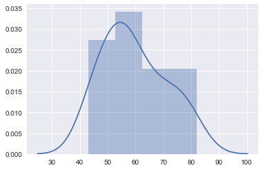

```python
info_df = repl_df_items(raw_data, 'info', None, 30)
data = []

collision_df = info_df[(info_df['info_type'] == 'uas_collision') & (info_df['package_center'] == 0) ].drop_duplicates('other2')

num_collisions_df = pd.pivot_table(collision_df,index=["replication"], values=['other'], aggfunc='count')
num_collisions = num_collisions_df.as_matrix().flatten()
data.append(num_collisions)

mean = np.mean(num_collisions)
CI = st.t.interval(0.95, len(num_collisions)-1, loc=mean, scale=st.sem(num_collisions))

print('Collisions - Mean: {:.2f}; SE: {}, CI: {}'.format(mean, st.sem(num_collisions), CI))
sns.distplot(num_collisions)
# info_df
```

```
Collisions - Mean: 61.90; SE: 1.484285500931631, CI: (58.86429529610684, 64.93570470389315)
```

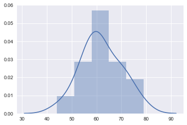

```python
collision_df = info_df[(info_df['info_type'] == 'uas_collision') & (info_df['package_center'] == 1) ].drop_duplicates('other2')

num_collisions_df = pd.pivot_table(collision_df,index=["replication"], values=['other'], aggfunc='count')
num_collisions = num_collisions_df.as_matrix().flatten()

mean = np.mean(num_collisions)
CI = st.t.interval(0.95, len(num_collisions)-1, loc=mean, scale=st.sem(num_collisions))

print('Collisions - Mean: {:.2f}; SE: {}, CI: {}'.format(mean, st.sem(num_collisions), CI))
sns.distplot(num_collisions)
# info_df
data.append(num_collisions)
```

```python
import pickle
with open('data/collisions_dual.p', 'wb') as handle:
    pickle.dump(data, handle)
```